# 17.2. S4 Classes

S4 classes are more formal than S3, in that you explicitly define classes with *slots* (for object variables) and *methods* for the objects.

[Bioconductor](https://bioconductor.org) makes extensive use of `S4` classes.

The S4 system provides *functional* OOP.

# 17.2.1 S4 Tools

The two main programming tools are

- `setClass()` to define a class of objects and
- `setMethod()` to define methods for a function, corresponding to classes for one or more arguments.

Both these are programming tools that store the definitions; calls to them should be in the source code for a package.

Think of them like the Python `class` and `def` statements, as part of the language. (See Chapters 9 and 10 of Chambers Software for Data Analysis.)

To create a new class definition:

```
setClass(Class, slots = , contains = )
```

where `Class` is the named for the new class, `slots` is a named list of the classes for the slots and `contains` is a vector of one or more inherited classes.

In lecture 12, Prof. Chambers showed a `track` class implemented in S4.

```r
track <- setClass("track",
                  slots = c(lat = "numeric", long = "numeric", time = "Date"))
```

This class has separate slots for the variables (`lat`, `long`, `time`). For example, you may consider defining specialized classes even for latitude and longitude!

# 17.2.2. A Complete Example of S4

We’ll create a class to represent a stock object along with data about its ticker symbol and prices.

```r
setClass("Stock", representation(symbol = "character",
                                 data = "data.frame")
         )
```

We’ve defined a simple class with two slots. So we can construct this object and print it out.

```r
s <- new("Stock")
s
```

```
## An object of class "Stock"
## Slot "symbol":
## character(0)
##
## Slot "data":
## data frame with 0 columns and 0 rows
```

The printed representation (result of the default `show` method) is not very appealing. Better to define a `show` method to print it (`show` is a generic).

```r
show
```

```
## standardGeneric for "show" defined from package "methods"
##
## function (object)
## standardGeneric("show")
## <bytecode: 0x7fae68a75cc8>
## <environment: 0x7fae644ac3f0>
## Methods may be defined for arguments: object
## Use  showMethods("show")  for currently available ones.
## (This generic function excludes non-simple inheritance; see ?setIs)
```

Here is our `show` method for our `Stock` class. Note the use of the `signature` that indicates that this `show` method applies to our `Stock` class.

```r
setMethod(f = "show", signature = "Stock",
          definition = function(object) {
              cat(sprintf("Stock Symbol: %s \n", object@symbol))
              if (nrow(object@data) > 0) {
                  cat(sprintf("%d prices\n", nrow(object@data)))
              } else {
                  cat("No data in object slots.\n")
              }
          })
```

We can try it.

```r
s
```

[output not shown]

A stock class with some data.

```r
s <- new("Stock", symbol = "JUNK",
         data = data.frame(price = rnorm(10, mean = 200, sd = 5),
                           date = as.Date(Sys.Date()) - 1:10))
```

Print it out.

```r
s
```

```
## Stock Symbol: JUNK
## 10 prices
```

Maybe we want to have some default data in the constructor. Let us use some random data. (You can pull in `AAPL` stock for the last 10 days if that makes sense in your application or something like that.)

```r
setClass("Stock", representation(symbol = "character",
                                 data = "data.frame"),
         prototype = prototype (
             symbol = "JUNK",
             data = data.frame(price = rnorm(10, mean = 100, sd = 5),
                               date = as.Date(Sys.Date()) - 1:10))
         )
```

Now, if you use the constructor without data, you’ll get the default object.

```r
s2 <- new("Stock")
s2
```

```
## Stock Symbol: JUNK
## 10 prices
```

# 17.2.3. Slots

Fields in the object are called *slots* and are accessed using the `@` symbol. You can get info about slots using the following functions.

```r
slotNames("Stock")
```

```
## [1] "symbol" "data"
```

```r
getSlots("Stock")
```

```
##       symbol         data
##  "character" "data.frame"
```

```r
s2@symbol
```

```
## [1] "JUNK"
```

```r
str(s2@data)
```

```
## 'data.frame':    10 obs. of  2 variables:
##  $ price: num  105.1 103.6 101.3 93.4 97.6 ...
##  $ date : Date, format: "2020-02-13" "2020-02-12" ...
```

The above (using the `@` symbol) is not a good way to work with slots. In object oriented programming, one creates accessor and modifier functions to deal with object properties. So once again we need *methods*.

### 17.2.3.1. First Attempt

One would think the following would do the trick, following on our previous example of `show`

```r
setMethod("getSymbol", "Stock",
          function(object) object@symbol
          )
```

```
## Error in setMethod("getSymbol", "Stock", function(object) object@symbol): no existing definition for function 'getSymbol'
```

But that doesn’t work because R does not know of any generic function called `getSymbol`. The `setMethod` assumes you are defining a method for a *generic* function. (See `?setMethod`)

### 17.2.3.2. Correct Way

Therefore, the following incantation is standard.

```r
setGeneric("getSymbol", function(object) standardGeneric("getSymbol") )
```

```
## [1] "getSymbol"
```

```r
setMethod("getSymbol", "Stock",
          function(object) object@symbol
          )
```

*That is, you make a generic function, and then define a method for the generic.*

Now let’s try using it.

```r
getSymbol(s2)
```

```
## [1] "JUNK"
```

This leads to an interesting situation. What happens if you, as a user, have imported a package that already contains a generic named `getSymbol`? (You’ll get a warning that things are masked. That’s ok.)

Setting the value of a slot proceeds similarly, except now note the `value` argument.

```r
setGeneric("setSymbol", function(object, value) standardGeneric("setSymbol") )
```

```
## [1] "setSymbol"
```

```r
setMethod("setSymbol", "Stock",
          function(object, value) object@symbol <- value
          )
```

Does it work? Let us see.

```r
setSymbol(s2, "FOO")
s2
```

```
## Stock Symbol: JUNK
## 10 prices
```

Hmmm, nothing changed. Why? Because for setting, we need *reference* semantics!

We have to use a special construct, a *replacement* function we discussed in an earlier lecture.

```r
rm("setSymbol")
setGeneric("setSymbol<-", function(object, value) standardGeneric("setSymbol<-") )
```

```
## [1] "setSymbol<-"
```

```r
setReplaceMethod(f = "setSymbol",
                 signature = "Stock",
                 definition = function(object, value) {
                     object@symbol <- value
                     object
                 })
```

```r
setSymbol(s2) <- "FOO"
s2
```

```
## Stock Symbol: FOO
## 10 prices
```

Ditto for slot `data`.

```r
setGeneric("getData", function(object) standardGeneric("getData") )
```

```
## [1] "getData"
```

```r
setMethod("getData", "Stock",
          function(object) object@data
          )

setGeneric("setData<-", function(object, value) standardGeneric("setData<-") )
```

```
## [1] "setData<-"
```

```r
setReplaceMethod(f = "setData",
                 signature = "Stock",
                 definition = function(object, value) {
                     object@data <- value
                     object
                 })
```

The modified object *has to be returned* as the value of the function definition.

In the above, we are setting slot values without verifying its contents. We can do better.

# 17.2.4. The `validity` method

Often, when one sets data in an object slot, one would like to perform some sanity checks so that there are no inconsistencies.

You can define a validity method for a class at any time, either during its definition by using `validity` parameter or defining a function and later adding it using `setValidity`. We’ll do the latter.

```r
stockValidity <- function(object) {
    retVal <- NULL
    if (!is.data.frame(object@data)) {
        retVal <- c(retVal, "Data slot is not a data frame!")
    }
    dfNames <- sort(names(object@data))
    expectedNames <- c("date", "price")
    if (length(expectedNames) != length(dfNames) ||
        !all.equal(expectedNames, dfNames)) {
        retVal <- c(retVal, "Names mismatch")
    }
    stockSymbol <- object@symbol
    if ((!is.character(stockSymbol)) || (length(stockSymbol) != 1L) ||
        (nchar(stockSymbol) == 0)) {
        retVal <- c(retVal, "Bad Stock Symbol")
    }
    if (is.null(retVal))
        TRUE
    else
        retVal
}
setValidity("Stock", stockValidity)
```

```
## Class "Stock" [in ".GlobalEnv"]
##
## Slots:
##
## Name:      symbol       data
## Class:  character data.frame
```

Let’s now check is `s2` is valid.

```r
validObject(s2)
```

```
## [1] TRUE
```

We can even reuse this in the `setData` and `setSymbol` functions.

```r
setReplaceMethod(f = "setSymbol",
                 signature = "Stock",
                 definition = function(object, value) {
                     object@symbol <- value
                     validObject(object)
                     object
                 })

setReplaceMethod(f = "setData",
                 signature = "Stock",
                 definition = function(object, value) {
                     object@data <- value
                     validObject(object)
                     object
                 })
```

Let us now try it.

```r
setSymbol(s2) <- NULL
```

```
## Error in (function (cl, name, valueClass) : assignment of an object of class "NULL" is not valid for @'symbol' in an object of class "Stock"; is(value, "character") is not TRUE
```

```r
setSymbol(s2) <- ""
```

```
## Error in validObject(object): invalid class "Stock" object: Bad Stock Symbol
```

In case you are wondering, note that `s2` is not modified!

```r
s2
```

```
## Stock Symbol: FOO
## 10 prices
```

# 17.2.5. Initialization

The `S4` object system provides a way for you to define your own initialization function. For example, we might use the above validation in our initialization as follows.

```r
setMethod("initialize", "Stock",
          function (.Object, symbol, data) {
              if (missing(symbol) || missing(data)) {
                  stop("Symbol and data required")
              }
              .Object@symbol <- symbol
              .Object@data <- data
              validObject(.Object)
              .Object
          })
```

It is common to use validity functions in the initialization also.

# 17.2.6. Plotting

Let us do something more useful and define a plot method, that will plot the data using `ggplot2::qplot`.

```r
library(ggplot2)
setMethod("plot", "Stock",
          function(object) {
              data <- object@data
              qplot(data$date, data$price, data = data, geom = "line")
          })
```

```
## Error in conformMethod(signature, mnames, fnames, f, fdef, definition): in method for 'plot' with signature 'x="Stock"': formal arguments (x = "Stock", y = "Stock") omitted in the method definition cannot be in the signature
```

Note that there is no need to declare `plot` a generic since `plot` is already so.

This does not work. Because plot takes arguments `x` and `y`. So have to redefine using those parameters!

```r
setMethod("plot", "Stock",
          function(x, y, ...) {
              data <- x@data
              qplot(data$date, data$price, data = data, geom = "line")
          })
```

Now we can use it.

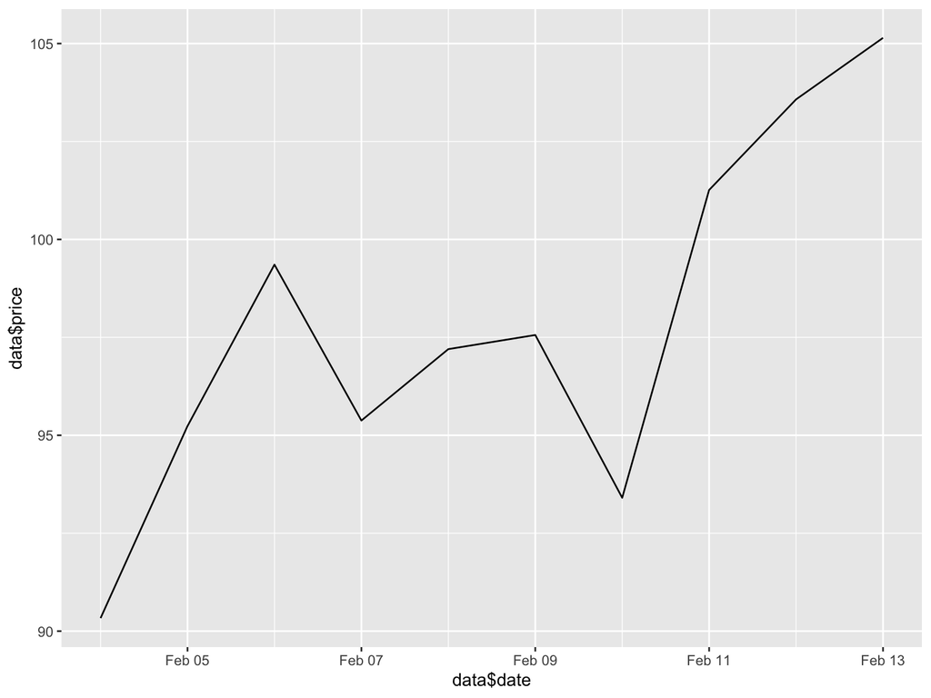

```r
plot(s2)
```

___

# 17.2.7. S4 in Packages

Packages that use S4 classes must import all of `methods`. They should also export the classes they define. The Roxygen tag for this is `@exportClass`.

I have included an example package utilizing the stock S4 example for you.

# 17.2.8. References and Suggested Reading

Chapter 10 of Extending R is a complete introduction to this OOP paradigm.

Another readable reference I have found is *A (Not So) Short Introduction to S4* by Christophe Genolini. Google it.

For S4 in packages, Hadley Wickham’s `Advanced R` has tips on documentation.